# QPLOT

Aitor Vázquez Veloso

8/9/2021

En este documento se recoge una pequeña explicación de la función **qplot**, elaborada para practicar yo mismo con ella y, además, probar el uso de **RMarkdown**. **qplot** (quick plot), que es una función auxiliar del paquete ggplot2, reduce la complejidad de la graficación. Para utilizarla, cargamos la librería y los datos que nos proporciona de ejemplo.

```r
library(ggplot2)
data("diamonds")  # es un df que viene por defecto con el paquete ggplot2
```

## Estructura principal de la función qplot

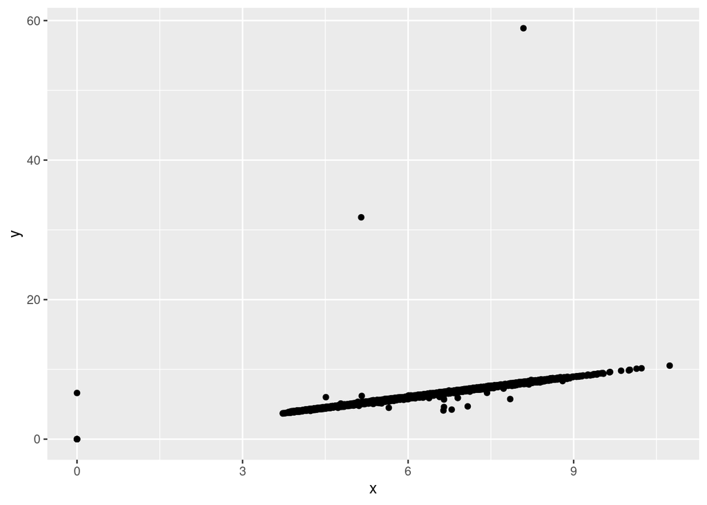

```r
qplot(  #función para dibujar las gráficas
        x,  # columna x del df
        y,  # columna y del df
        data = diamonds  # df a utilizar, al cual pertenecen las columnas x e y
)
```

## Cálculos directamente en la graficación

**qplot** permite realizar cálculos sobre las columnas ya existentes en un df en el momento de graficar; de este modo, se pueden combinar columnas entre sí o modificar la escala de los datos.  
Ejemplo para hacer una *transformación logarítmica*:

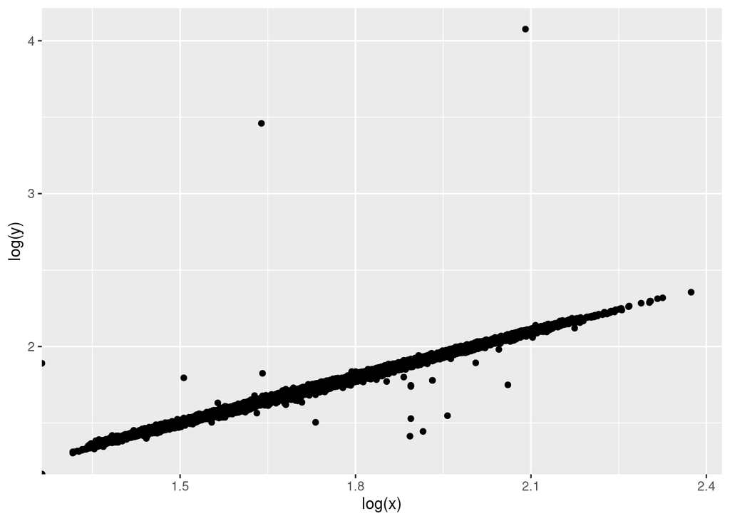

```r
qplot(
        log(x),
        log(y),
        data = diamonds
)
```

ó

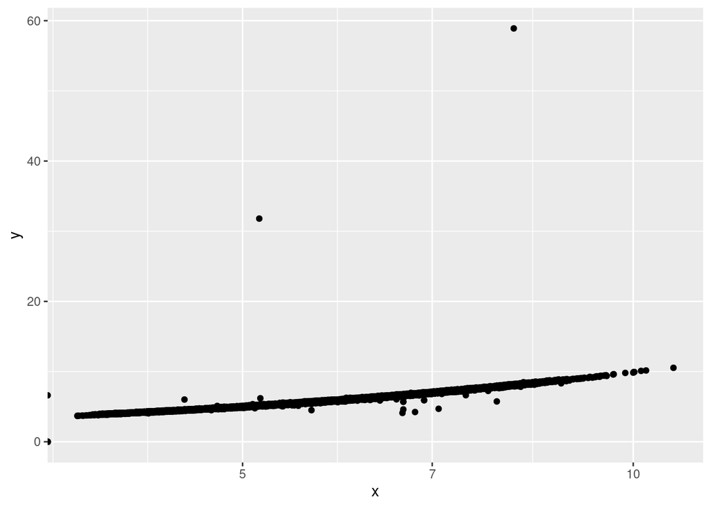

```r
qplot(
        x,
        y,
        log = c("x", "y"),
        data = diamonds
)
```

Otra posibilidad es la de *combinar columnas* entre sí o hacer *cambios de unidades* directamente en el gráfico

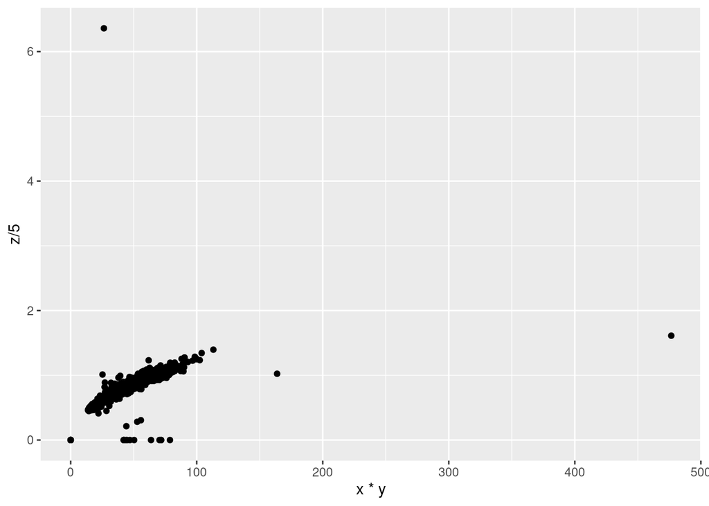

```r
qplot(
        x*y,
        z/5,
        data = diamonds
)
```

## Atributos estéticos básicos

El título se escribe con *main*.

Los títulos de los ejes se escriben con *xlab* e *ylab*.

Los límites del gráfico se escriben con *xlim* e *ylim*.

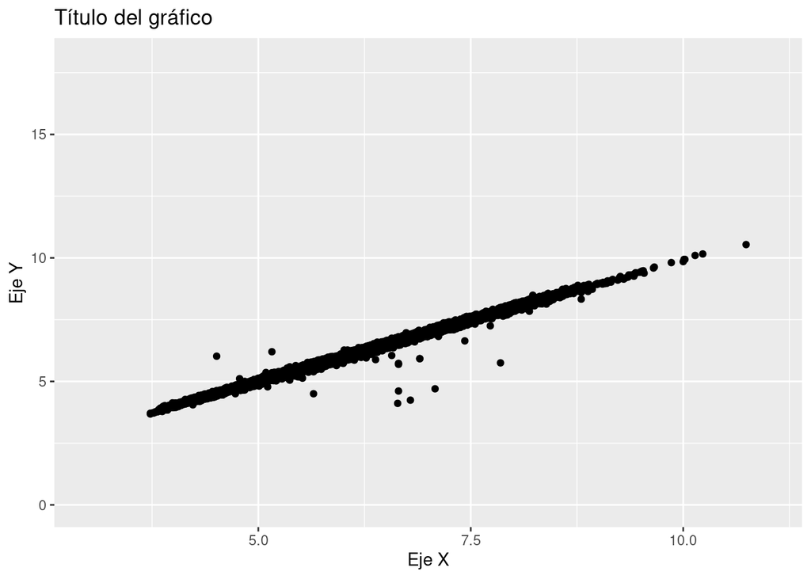

```r
qplot(
        x,
        y,
        data = diamonds,
        main = "Título del gráfico",  # título
        xlab = "Eje X",  # título del eje x
        ylab = "Eje Y",  # título del eje y
        xlim = c(3, 11),  # límite inferior y superior, eliminando del gráfico los puntos que sobrepasan los límites
        ylim = c(0, 18)  # límite inferior y superior, eliminando del gráfico los puntos que sobrepasan los límites
)
```

## Atributos estéticos avanzados

*color* permite modificar el color de los datos a graficar.

*shape* permite modificar la forma en la que se representan los datos (círculos, cuadrados, triángulos…).

*size* permite graficar distintos tamaños de puntos para una misma variable dependiendo de una categoría a la que pertenezcan los datos.

*alpha* permite reducir la densidad de puntos en la gráfica localizados muy próximos.

*color y shape* se usan para variables categóricas.

*size* se usa para variables numéricas.

Ejemplos:

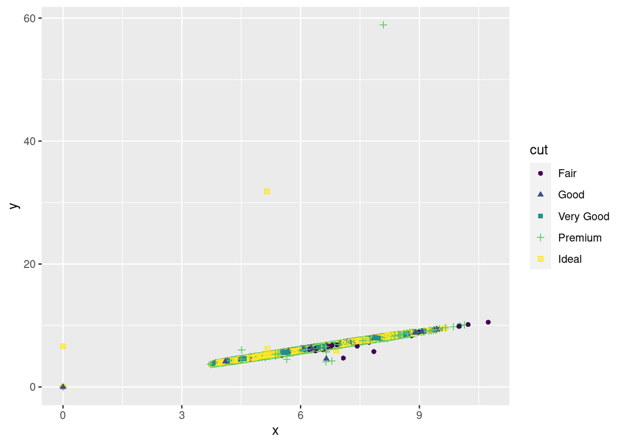

```r
qplot(
        x,
        y,
        data = diamonds,
        color = cut,  # color asignado auto. a cada categoría de la columna "cut"
        shape = cut  # forma asignada auto. a cada categoría de la columna "cut"
)
```

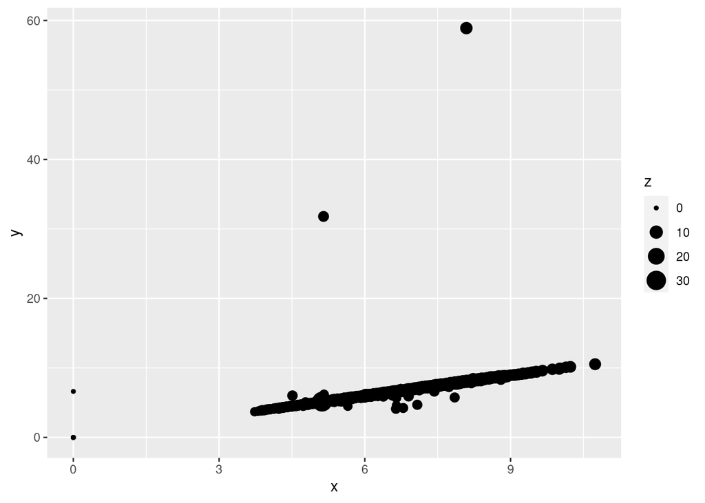

```r
qplot(
        x,
        y,
        data = diamonds,
        size = z  # tamaño de los puntos determinado por las categorías creadas auto. a partir de la variable z
)
```

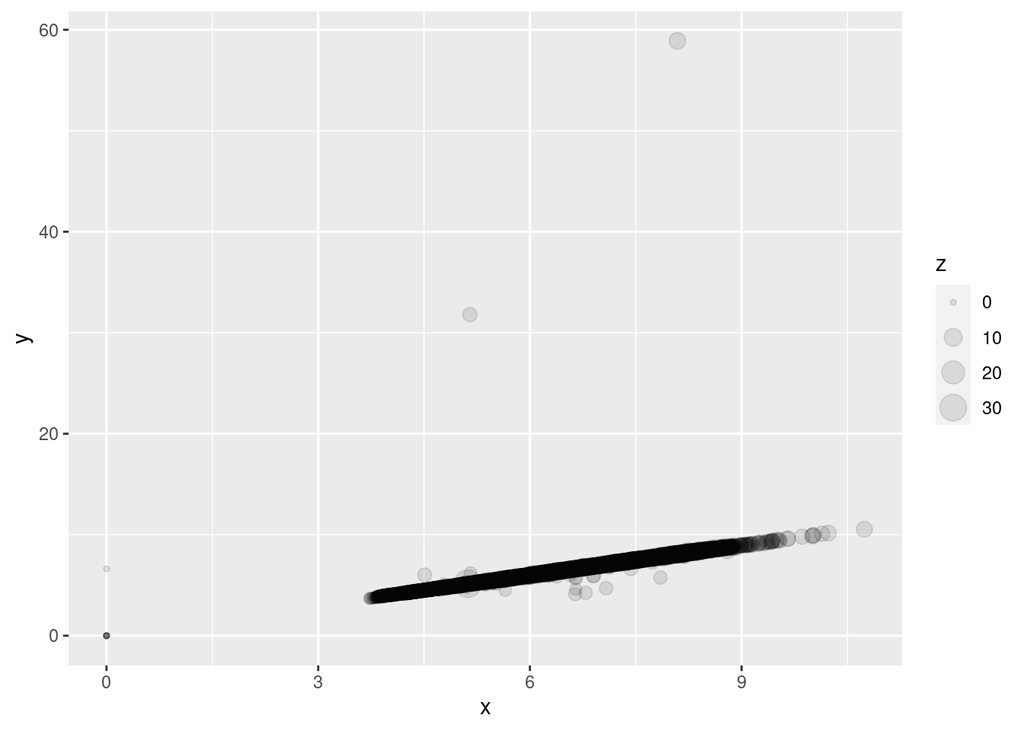

```r
qplot(
        x,
        y,
        data = diamonds,
        alpha = I(1/10), # para este ejemplo, estamos indicando que en la gráfica se muestre un punto de cada cien, de manera que se reducirá enormemente la densidad de puntos visual
        size = z  # tamaño de los puntos determinado por las categorías creadas auto. a partir de la variable z
)
```

### Sobre los colores

Para hacer gráficos vistosos importan, en cierto modo, los colores utilizados.

*colors()* nos devuelve la lista de colores disponibles.

*palette()* nos devuelve la lista de colores que actualmente están en la paleta que utilizan los gráficos.

Además, los siguientes comandos nos permiten cambiar las paletas de colores de nuestras gráficas a otras prediseñadas

*rainbow()*, escala con los colores del arco iris

*heat.colors()*, escala de calor que utiliza rojo > naranja > amarillo

*topo.colors()*, escala azul > verde > amarillo

*terrain.colors()*, escala verde > amarillo > marrón

Estas las podemos asignar utilizando los siguientes comandos:

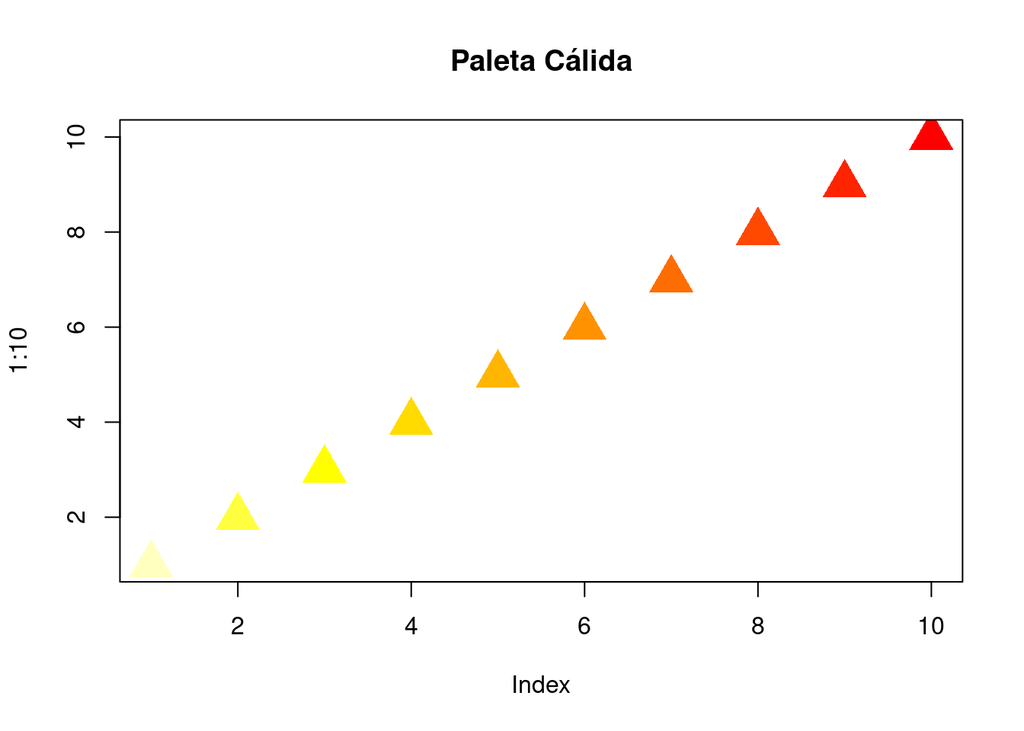

```r
paleta_1 <- heat.colors(10,  # asignamos una escala de 10 colores en este caso
                        rev = 1,  # invertimos el orden de los colores
                        alpha = NULL)  # NO asignamos transparencia
palette(paleta_1)  # comando para cambiar la paleta de colores por defecto

# ejemplo de visualización
plot(1:10, col=1:10, main="Paleta Cálida",pch=17, cex=3)
```

Existen dos formas básicas de asignar una paleta de colores:

- forma 1: asignamos los colores que deseamos a una variable, y esta la ponemos como argumento del gráfico

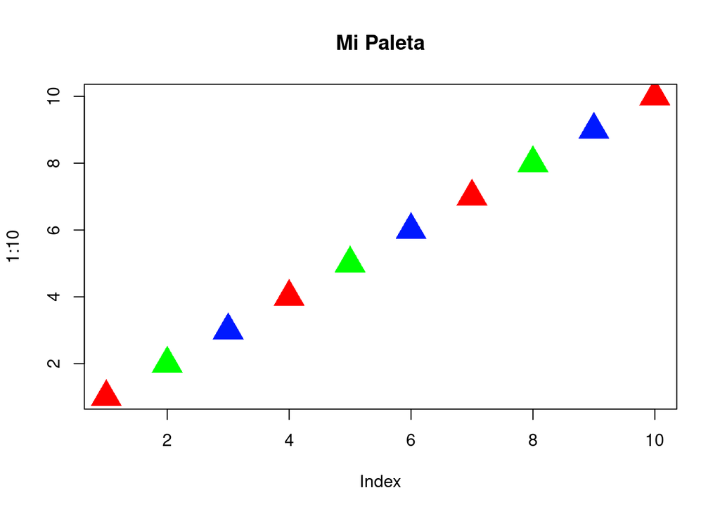

```r
mi_paleta <- c("red", "green", "#0019FFFF")
plot(1:10, col=mi_paleta, main="Mi Paleta",pch=17, cex=3)
```

- forma 2: asignamos una variable que contiene los colores deseados a la paleta de colores de R, sin necesidad de ponerla como argumento en el gráfico

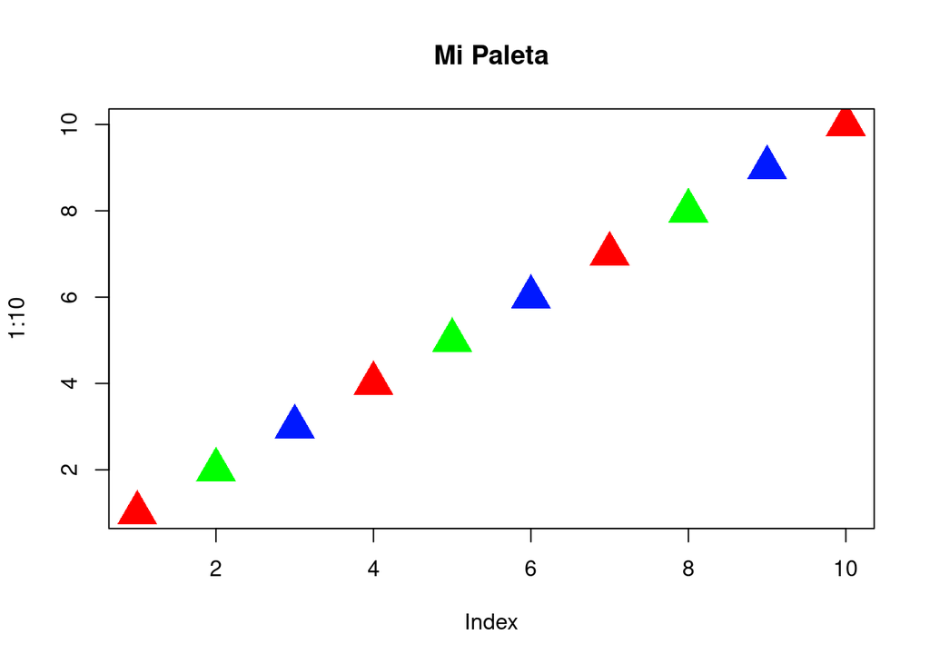

```r
palette(mi_paleta)
plot(1:10, col=1:10, main="Mi Paleta",pch=17, cex=3)
```

Forma por defecto de la paleta de colores (se restablece al cerrar R)

```r
palette("default")
```

## Forma y agrupación de gráficos

*asp* permite alterar el ratio y/x del gráfico, es decir, cambiar las dimensiones x e y del gráfico, estirándolo horizontal o verticalmente.

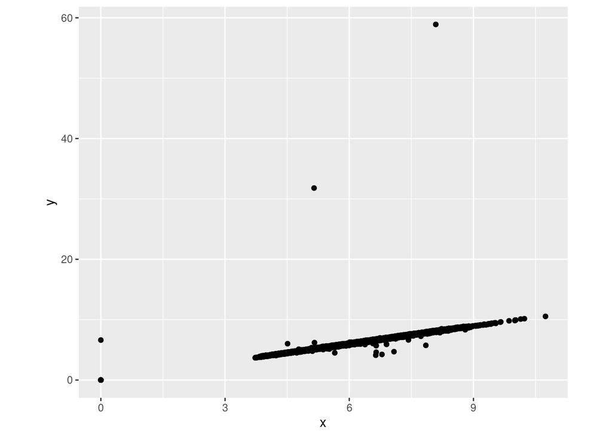

```r
qplot(
        x,
        y,
        data = diamonds,
        asp = 0.8  # modifica el ratio y/x del gráfico, disminuyendo la dimensión horizontal y haciendo el gráfico más cuadrado
)
```

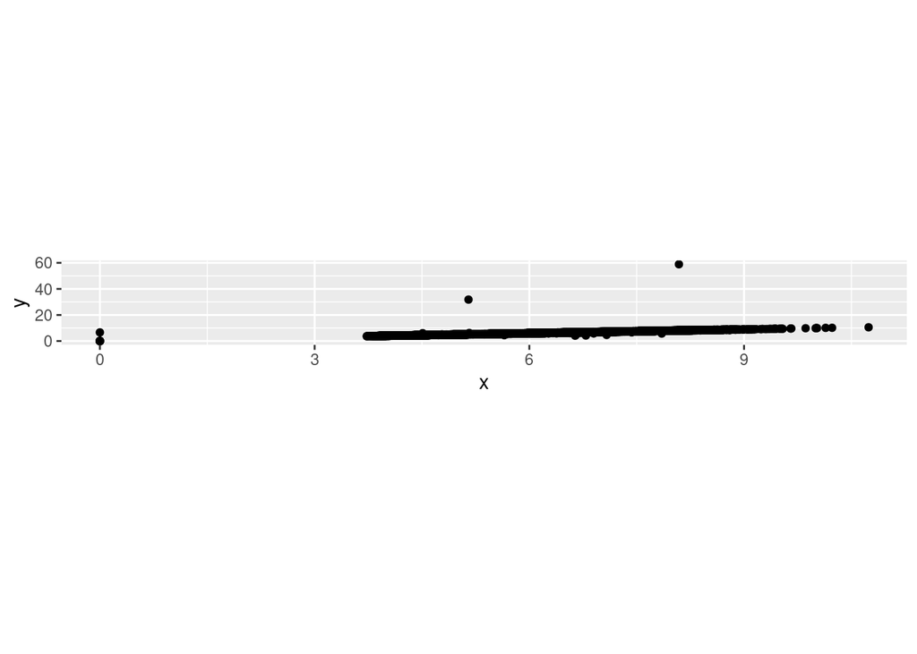

```r
qplot(
        x,
        y,
        data = diamonds,
        asp = 0.1  # modifica el ratio y/x del gráfico, aumentando la dimensión horizontal y haciendo el gráfico más alargado
)
```

*facets* nos permite subdividir el gráfico en tantos gráficos diferentes como campos cualitativos existan en la variable que le indiquemos.

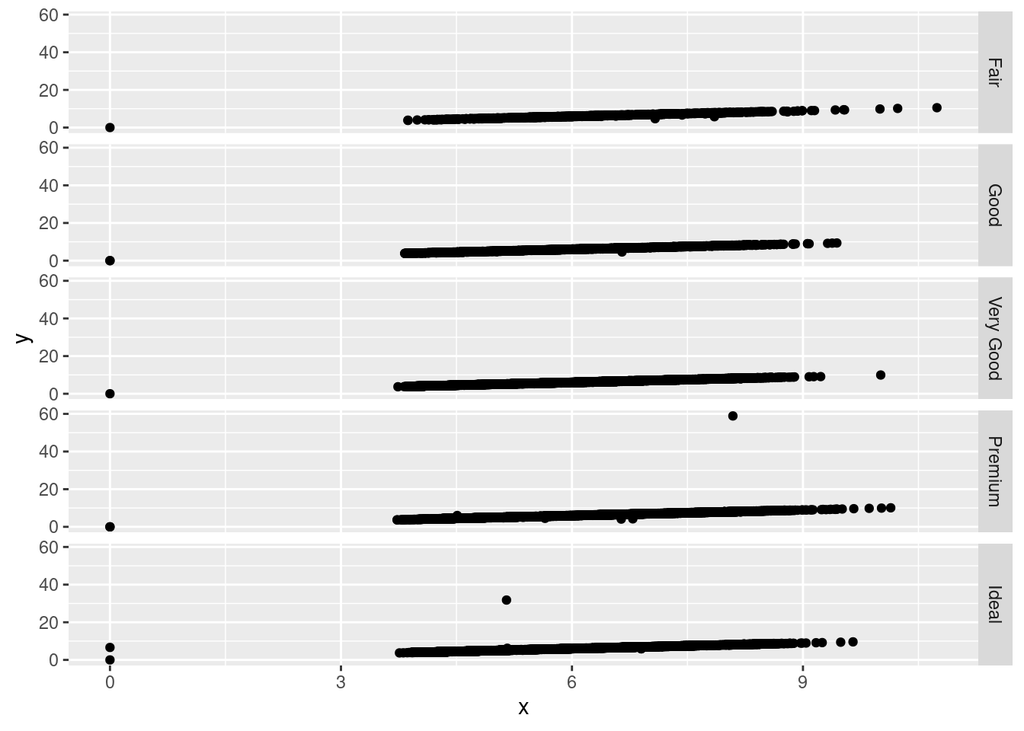

```r
qplot(
        x,
        y,
        data = diamonds,
        facets = cut ~ .  # de este modo, indicamos que cree tantos gráficos como categorías diferentes existan en la variable "cut"
)
```

## Tipos de gráficos

Para modificar el tipo de gráfico que queremos dibujar utilizaremos el argumento *geom()* de la función **qplot**.

### Gráficos que combinan puntos con líneas y/o texto

*geom = c(“point”, “line/smooth/text”)* nos dibuja sobre la gráfica los puntos (*point*) y otra opción que le enviemos:

*line* dibuja una línea que une los puntos estamos pintando

*smooth* dibuja una línea que se ajusta a los datos que estamos pintando y, además, su error estándar

*text* nos dibuja el conenido de la variable que le asociemos con label

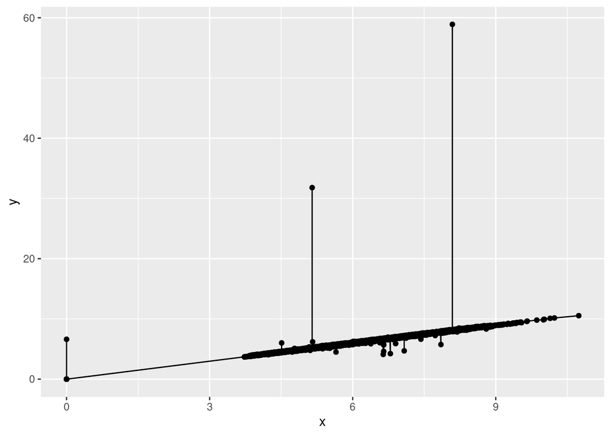

```r
qplot(
        x,
        y,
        data = diamonds,
        geom = c("point", "line")  # puntos unidos por una línea
)
```

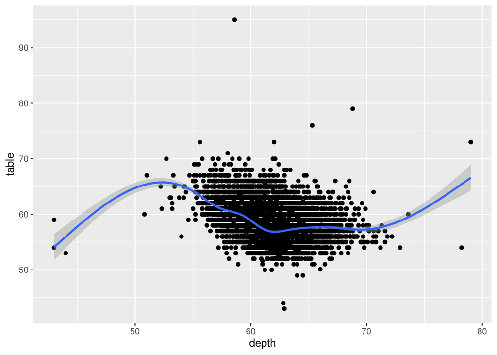

```r
qplot(
        depth,
        table,
        data = diamonds,
        geom = c("point", "smooth")  # línea ajustada a los datos con error estándar
)
```

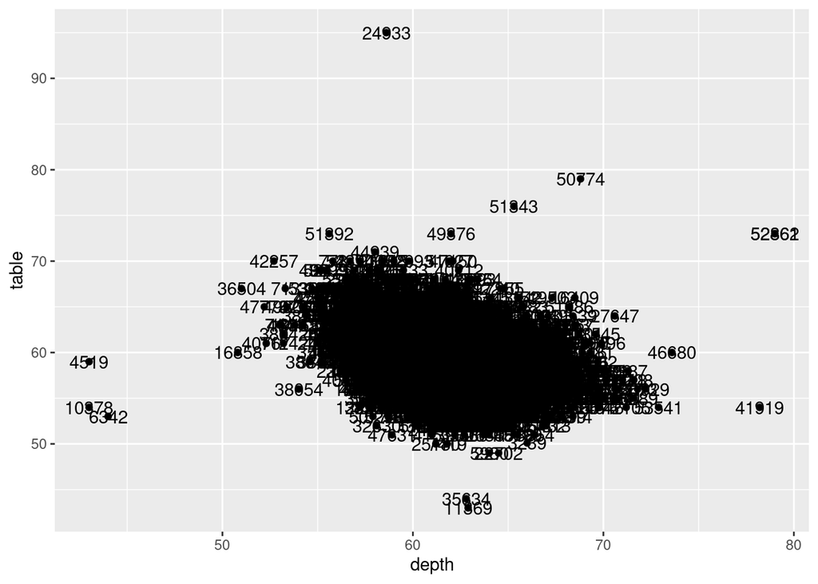

```r
qplot(
        depth,
        table,
        data = diamonds,
        label = rownames(diamonds),
        geom = c("point", "text")  # puntos con texto
)
```

### Gráficos que agrupan puntos

*geom = “jitter”* nos permite observar los datos por grupos, es decir, generar varios “subgráficos” utilizando una variable categórica para diferenciarlos

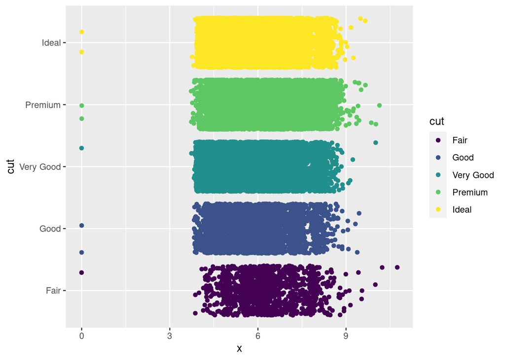

```r
qplot(
        x,
        cut,  # variable por la que categorizamos
        data = diamonds,
        geom = "jitter",  # nos permite observar por grupos los datos
        color = cut  # variable por la queremos hacer una diferenciación de color
)
```

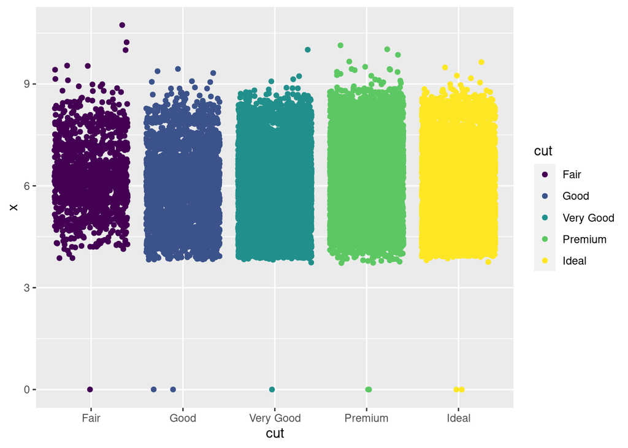

```r
qplot(
        cut,  # variable por la que categorizamos
        x,
        data = diamonds,
        geom = "jitter",  # nos permite observar por grupos los datos
        color = cut  # variable por la queremos hacer una diferenciación de color
)
```

Por otro lado, *geom = “boxplot”* permite realizar gráficos de cajas, configurando los demás parámetros igual que en el caso anterior.

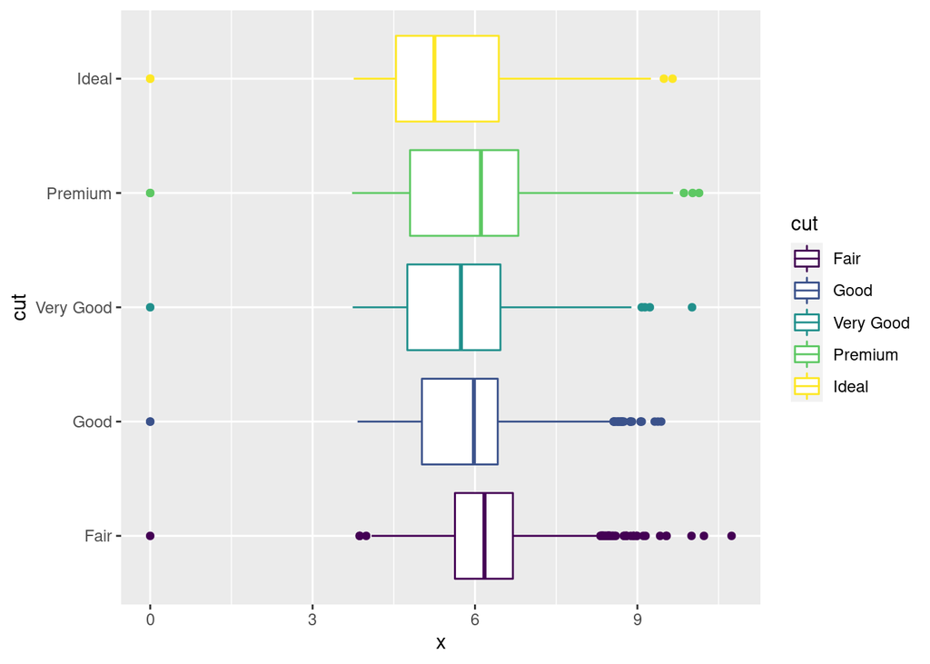

```r
qplot(
        x,
        cut,  # variable por la que categorizamos
        data = diamonds,
        geom = "boxplot",  # nos permite observar los datos agrupados en cajas
        color = cut  # variable por la queremos hacer una diferenciación de color
)
```

### Gráficos con líneas

*geom = “line”* nos dibuja líneas entre dos puntos, de manera que nos muestra los puntos unidos por una línea continua, la cual se genera de izquierda a derecha. Se usa para dibujar líneas temporales, principalmente.

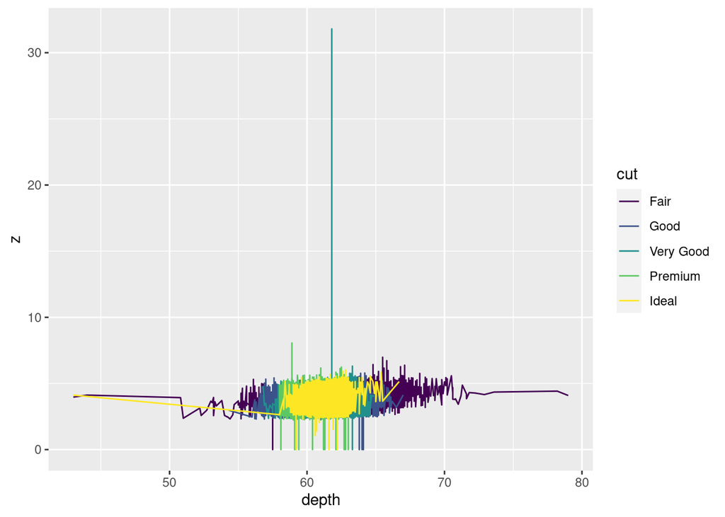

```r
qplot(
        depth,
        z,
        data = diamonds,
        geom = "line",  # nos permite dibujar líneas entre puntos
        color = cut  # variable por la queremos hacer una diferenciación de color
)
```

*geom = “path”* hace lo mismo que *line*, pero sin ir precisamente de izquierda a derecha (¿vecino más cercano?).

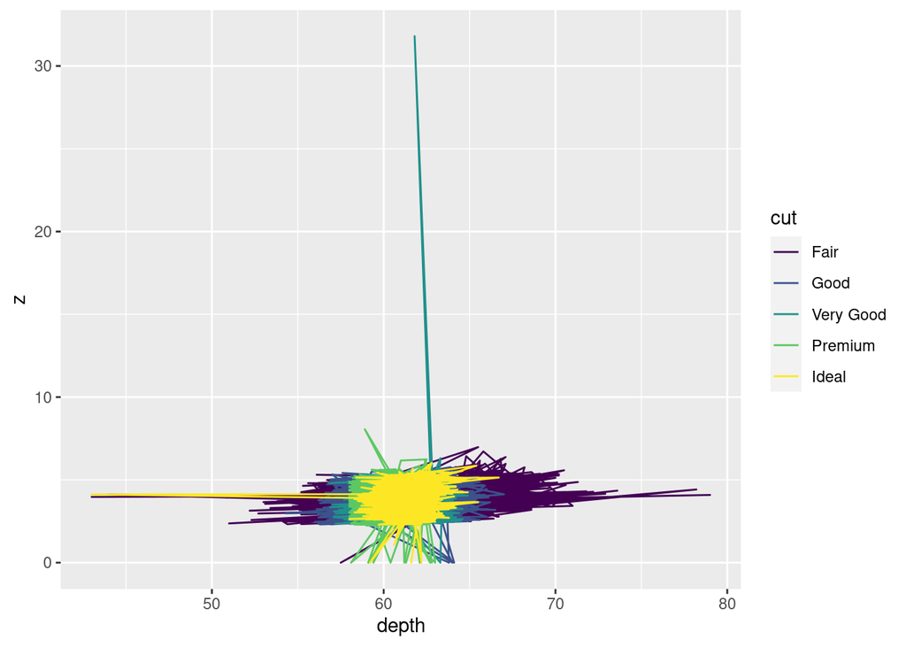

```r
qplot(
        depth,
        z,
        data = diamonds,
        geom = "path",  # nos permite dibujar líneas entre puntos
        color = cut  # variable por la queremos hacer una diferenciación de color
)
```

### Gráficas para una única variable

*geom = “histogram”* permite realizar un histograma, de manera que solo se grafica una única variable.

**NÓTESE que NO se indica una variable “y”, dado que no es necesaria**

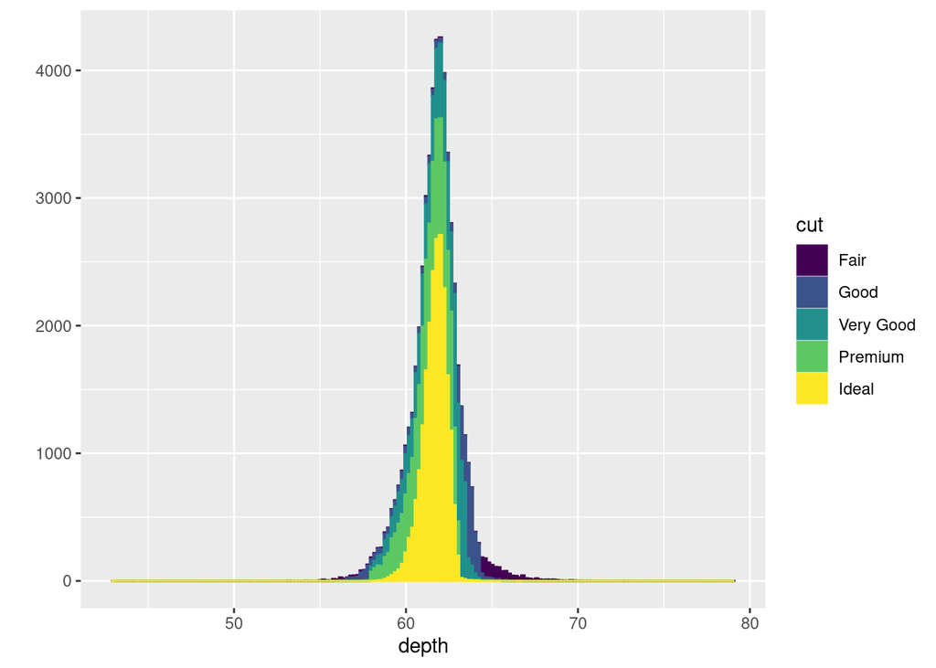

```r
qplot(
        depth,
        data = diamonds,
        binwidth = 0.2,  # permite modificar la escala del encho del histograma
        geom = "histogram",  # nos permite dibujar líneas entre puntos
        color = cut,  # cambiar el color de fuera
        fill=cut  # cambiar el color del interior
        #fill=I("lightgreen")  # cambiar el color del interior
)
```

*geom = “freqpoly”* nos genera un polinomio de frecuencias, es decir, es una línea que pasa por los “picos” del histograma anterior.

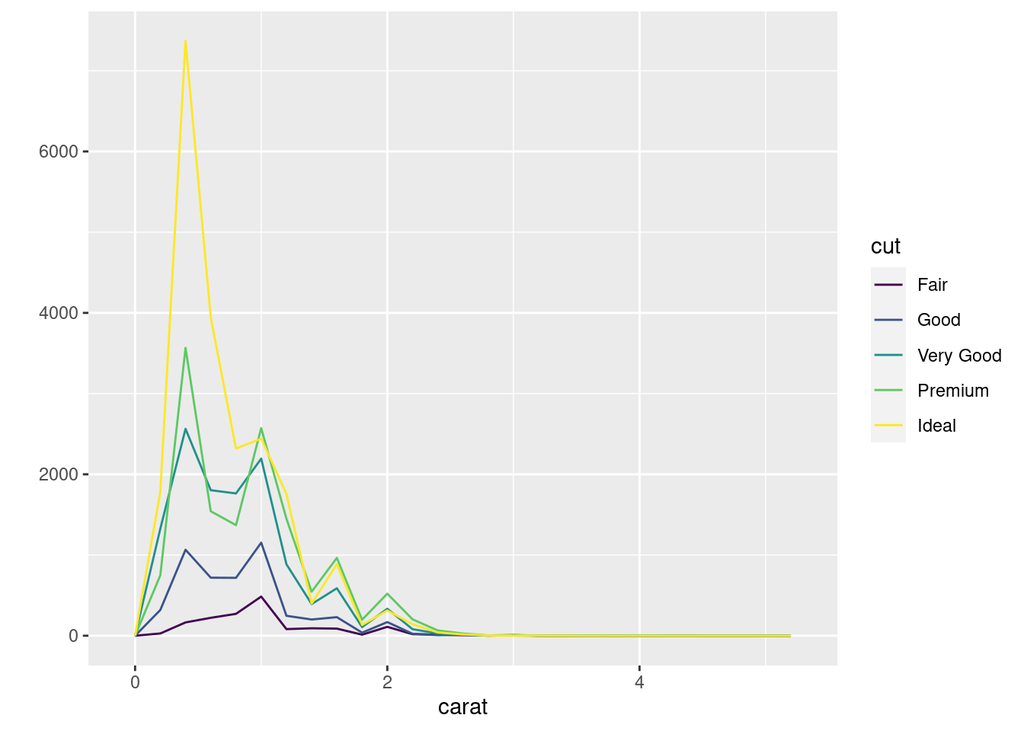

```r
qplot(
        carat,
        data = diamonds,
        binwidth = 0.2,  # permite modificar la escala del encho del polígono de frecuencias
        geom = "freqpoly",  # nos permite dibujar líneas entre puntos
        color = cut,  # cambiar el color
)
```

*geom = “density”* genera una gráfica de densidad de datos.

La diferencia con *freqpoly* es que en este caso son datos relativos al total (considerando 1 el 100% de datos), mientras que *freqpoly* nos devuelve los datos de frecuencia, es decir, el nº de veces que se repite un mismo dato.

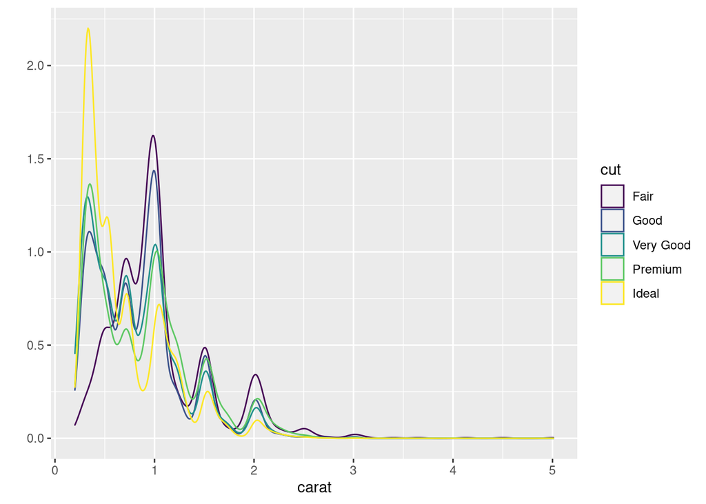

```r
qplot(
        carat,
        data = diamonds,
        geom = "density",  # nos permite dibujar la densidad de los datos
        color = cut,  # cambiar el color
)
```

Ambas opciones, histograma y línea, pueden combinarse de este modo:

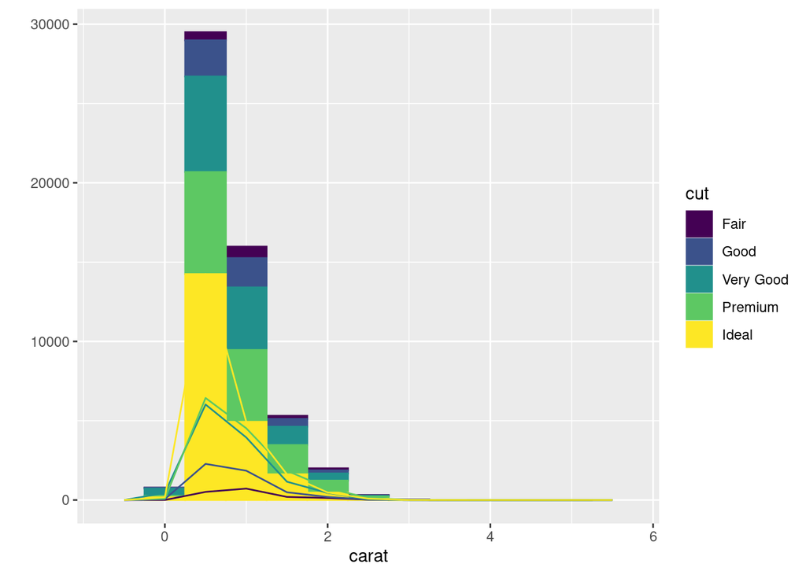

```r
qplot(
        carat,
        data = diamonds,
        binwidth = 0.5,
        geom = c("histogram", "freqpoly"),  # nos permite dibujar líneas entre puntos
        color = cut,  # cambiar el color de la línea
        #fill=I("lightgreen")  # cambiar el color del interior
        fill=cut  # cambiar el color del interior
)
```

## Compilación de comandos para los gráficos

Aquí se recopilan todos los comandos utilizados a lo largo del documento, que han de ser probados como se indica anteriormente para que funcionen correctamente.

```r
qplot(  #función para dibujar las gráficas
        x,  # columna x del df
        y,  # columna y del df
        data = df,  # df a utilizar, al cual pertenecen las columnas x e y
        main = "Título del gráfico",  # título
        xlab = "Eje X",  # título del eje x
        ylab = "Eje Y",  # título del eje y
        xlim = c(3, 11),  # límite inferior y superior, eliminando del gráfico los puntos que sobrepasan los límites
        ylim = c(0, 18),  # límite inferior y superior, eliminando del gráfico los puntos que sobrepasan los límites
        color = color,  # establece una serie de colores en las gráficas
        fill=cut,  # cambiar el color del interior (para cierto tipo de gráficos)
        fill=I("green"),  # cambiar el color del interior (para cierto tipo de gráficos)
        shape = z,  # de esta manera, damos formas diferentes a los distintos parámetros de la columna z; esto es útil para diferenciar variables cualitativas
        alpha = I(1/100),  # este comando nos permite reducir la densidad de puntos en la gráfica localizados muy próximos; de este modo, para el ejemplo, estamos indicando que en la gráfica se muestre un punto de cada cien, de manera que se reducirá enormemente la densidad de puntos visualmente
        size = z,  #pinta distintos tamaños de punto para cada una de las variables cuantitativas de la columna z; esto quizás no sea muy interesante
        facets = z ~ .,  # nos subdivide el gráfico en tantos gráficos diferentes como campos cualitativos existan en la variable "z"
        asp = 0.8,  # modifica el ratio y/x del gráfico, disminuyendo la dimensión horizontal y haciendo el gráfico más cuadrado
        label = rownames(diamonds),  # útil si uncluimos puntos con texto sobre el gráfico
        geom = c("point", "smooth", "text", "line"),  # nos dibuja sobre la gráfica los puntos (point), líneas (line), líneas de tendencia con error estándar (smooth) y texto (text, el cual debe ser indicado por medio del parámetro label)
        geom = "jitter",  # nos permite observar por cajas los datos que queremos
        geom = "boxplot",  # nos permite observar gráficos de cajas por las categorías que nosotros hemos establecido
        geom = "line",  # nos dibuja líneas entre dos puntos, de manera que nos muestra los puntos unidos por una línea continua, la cual se genera de izquierda a derecha; se usa para dibujar líneas temporales
        geom = "path",  # hace lo mismo que line, pero sin ir precisamente de izquierda a derecha
        geom = "histogram",  # nos permite visualizar los valores de una variable por medio de histogramas
        geom = "freqpoly",  # genera un polinomio de frecuencias
        geom = "density"  # dibuja una gráfica de densidad relativa
)
```